# linc-Cox2 KO vs WT (Embryonic)

## Differential Splicing

### Differential Isoforms between conditions

Per isoform difference between conditions:

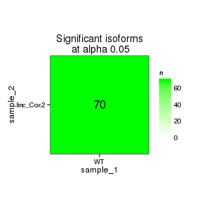

These isoforms are:

|  | isoAnnot$gene_short_name |
| --- | --- |
| 1 | Dynlt1c |
| 2 | Col1a1 |
| 3 | Rec8 |
| 4 | Zfp40 |
| 5 | Lama2 |
| 6 | Snrpf |
| 7 | Prpf8 |
| 8 | Dlx2 |
| 9 | Hcfc1r1 |
| 10 | Glo1 |
| 11 | Prss41 |
| 12 | Atp6v0c |
| 13 | Hn1l |
| 14 | Lox |
| 15 | Rps14 |
| 16 | Lbx1 |
| 17 | Fn1 |
| 18 | Bok |
| 19 | Asb1 |
| 20 | Mcm6 |
| 21 | Dbi |
| 22 | Lrp2 |
| 23 | Rps3a1 |
| 24 | Svep1 |
| 25 | Ski |
| 26 | Dera |
| 27 | Hddc3 |
| 28 | Dnah8 |
| 29 | Gbx2 |
| 30 | Rnps1 |
| 31 | Fam171a2 |
| 32 | Prr7 |
| 33 | Lars2 |
| 34 | 3110052M02Rik |
| 35 | Cldn11 |
| 36 | Vstm2l |
| 37 | Pcsk1n |
| 38 | Dgkz |
| 39 | Tlx3 |
| 40 | C1qtnf4 |
| 41 | 2310036O22Rik |
| 42 | Fmod |
| 43 | Dlgap3 |
| 44 | Reln |
| 45 | Hebp1 |
| 46 | Olfml2a |
| 47 | Hmga1 |
| 48 | Dmrta2 |
| 49 | Mafa |
| 50 | Col6a3 |
| 51 | Tagap1 |
| 52 | Hbb-y |
| 53 | Zfp771 |
| 54 | Pign |
| 55 | Capn11 |
| 56 | Sox11 |
| 57 | Sp9 |
| 58 | Gpr98 |
| 59 | Ssbp4 |
| 60 | Jund |
| 61 | Gpr27 |
| 62 | 9030025P20Rik |
| 63 | Gm11273 |
| 64 | Ccdc85c |
| 65 | Myl6 |
| 66 | Ccdc85b |
| 67 | Gm6472 |
| 68 | Gm9825 |
| 69 | Gm26917 |
| 70 | Gm26924 |

Gene-level DE isoform heatmap

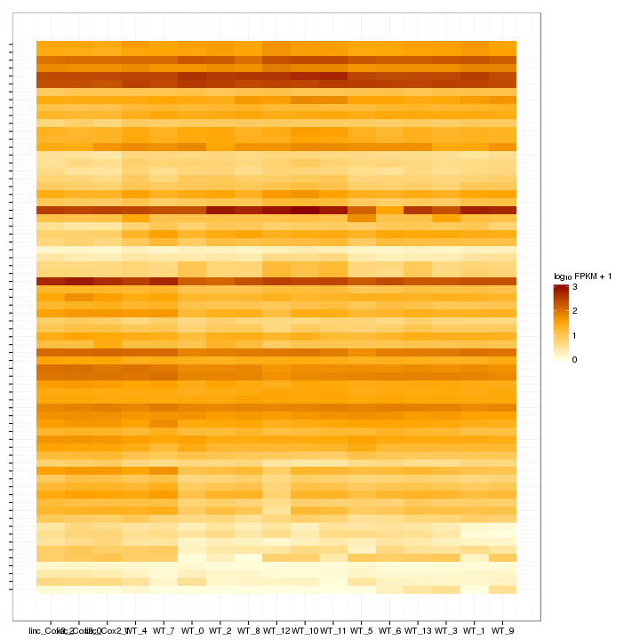

Isoform foldchange heatmap by isoform:

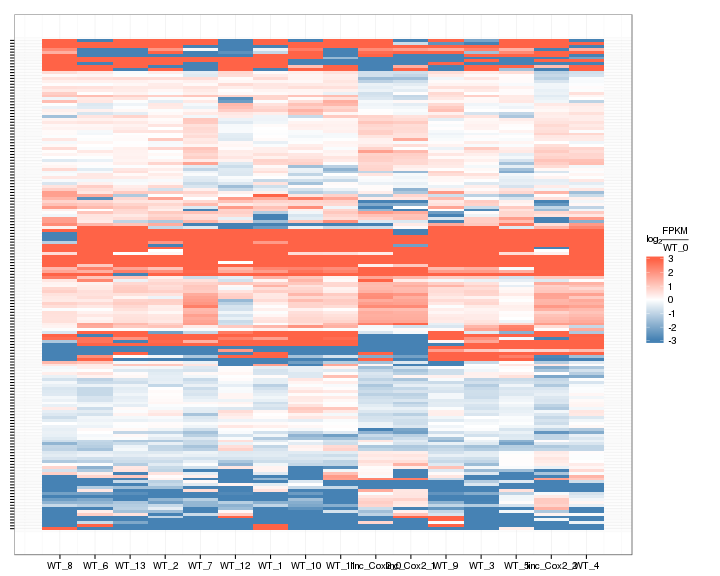

### Differential Splicing between conditions

(eval false for first pass)

# Gene/Pathway Analysis

## GSEA

Enrichment and zscores are calculated based on expression in KO vs WT (fpkmKO/fpkmWT), so genes that are down regulated in KO are shown in blue, while upregulation is shown in red.

KO/WT Blue = down in KO Red = Up in KO

Biocarta enrichment:

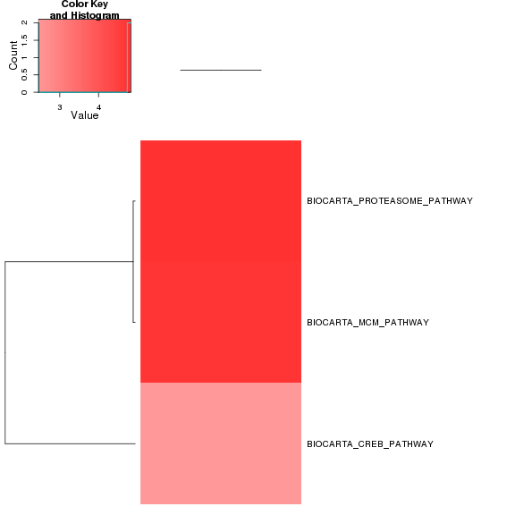

Biocarta zscore:

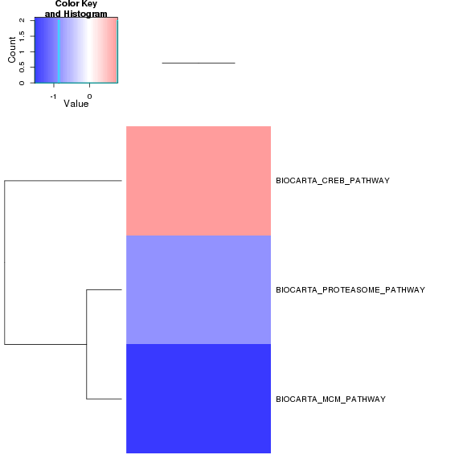

Reactome enrichment:

[output not shown]

[figure not shown]

Reactome zscore:

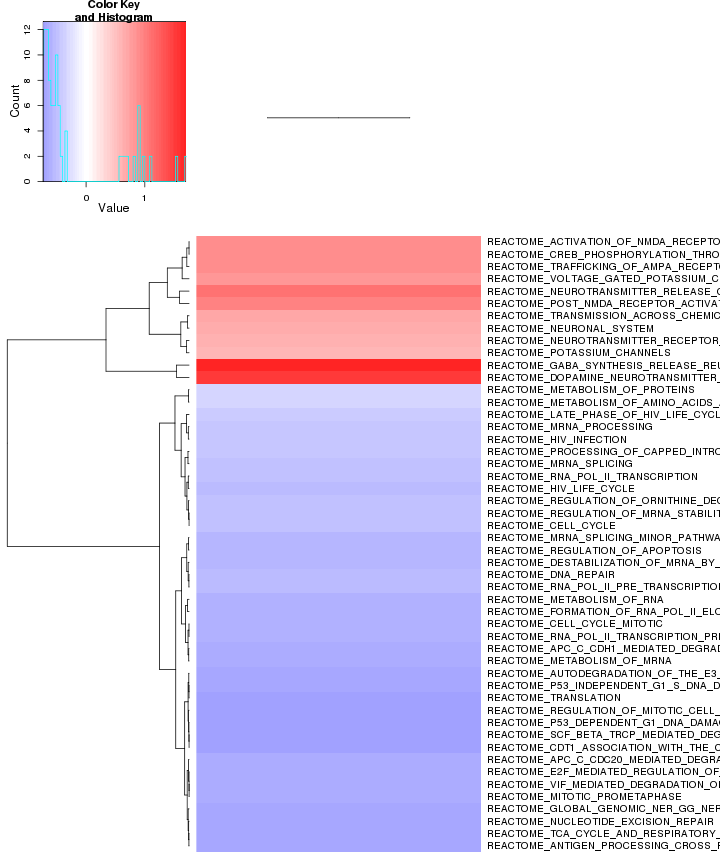

Kegg enrichment:

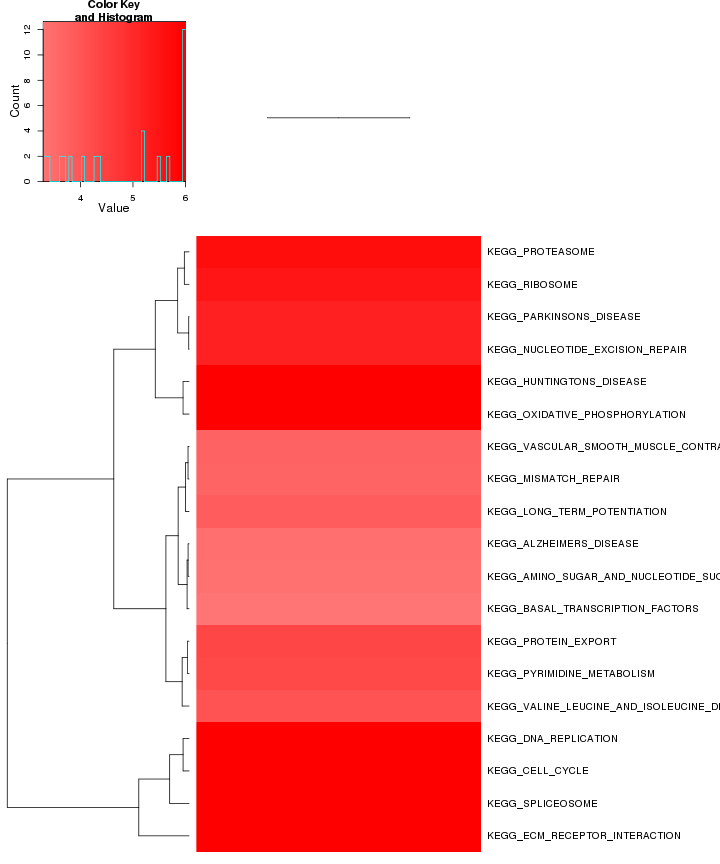

Kegg zscore:

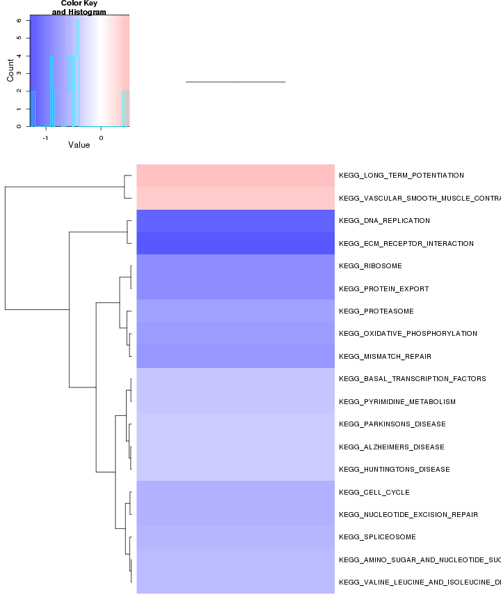

[output not shown]

[output not shown]

[output not shown]

[output not shown]

[output not shown]

Oncogene enrichment:

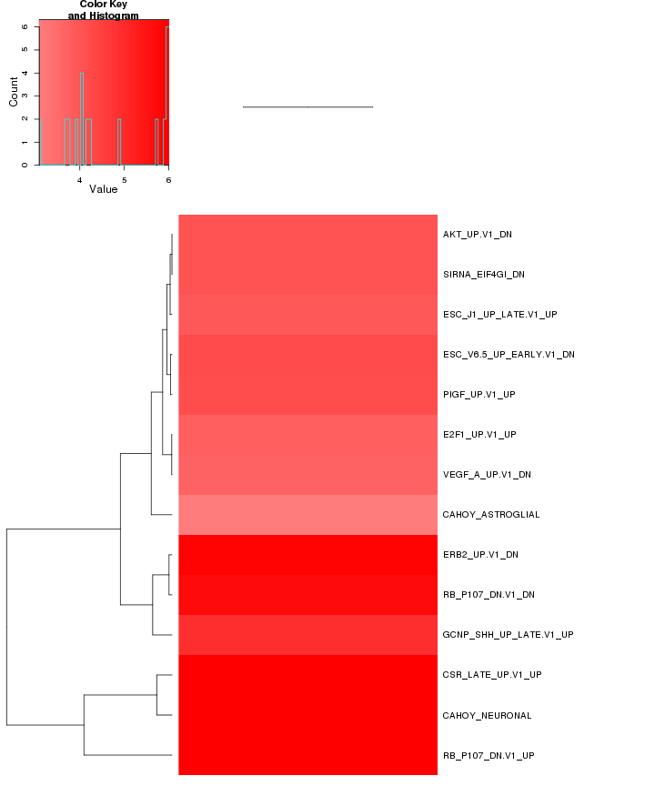

Oncogene zscore:

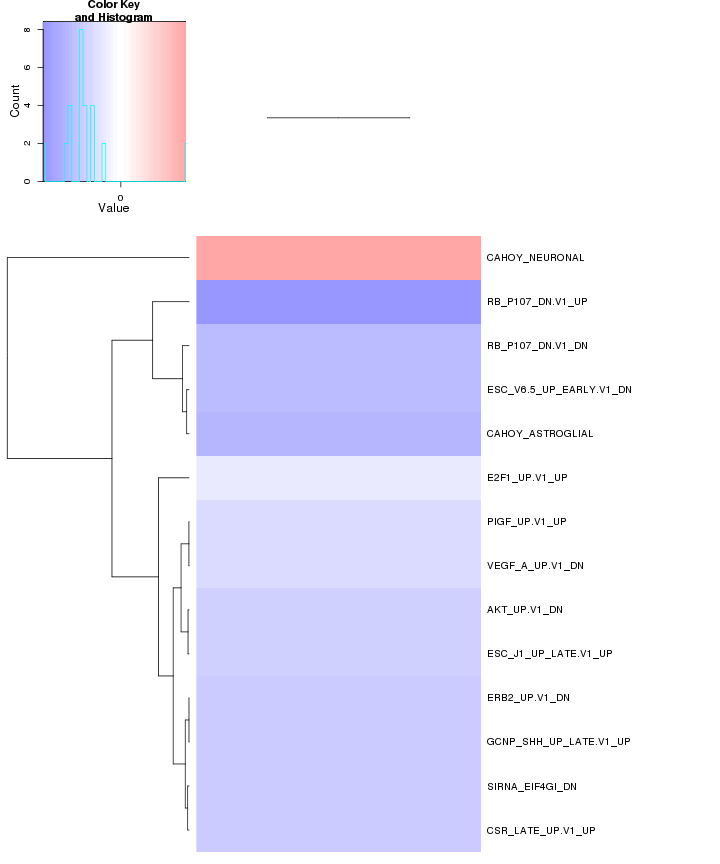

Immuno enrichment:

[output not shown]

[figure not shown]

Immuno zscore:

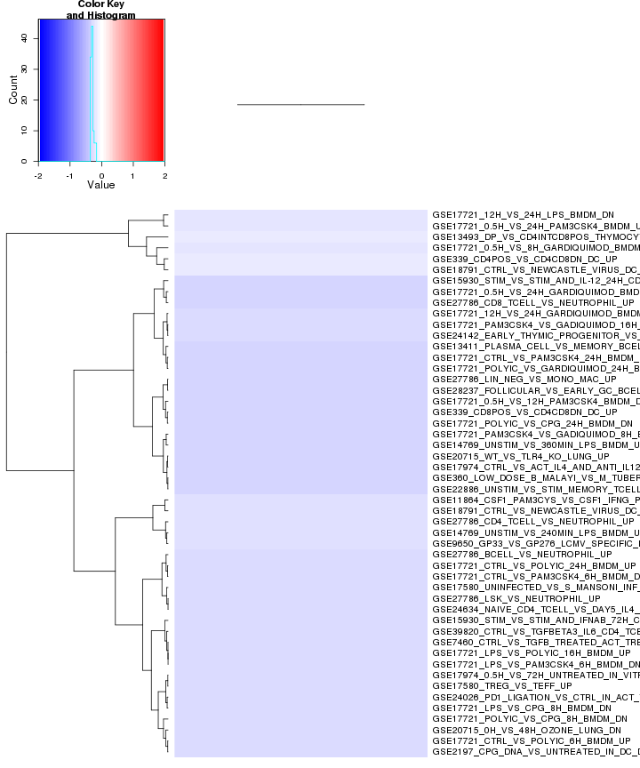

TF enrichment:

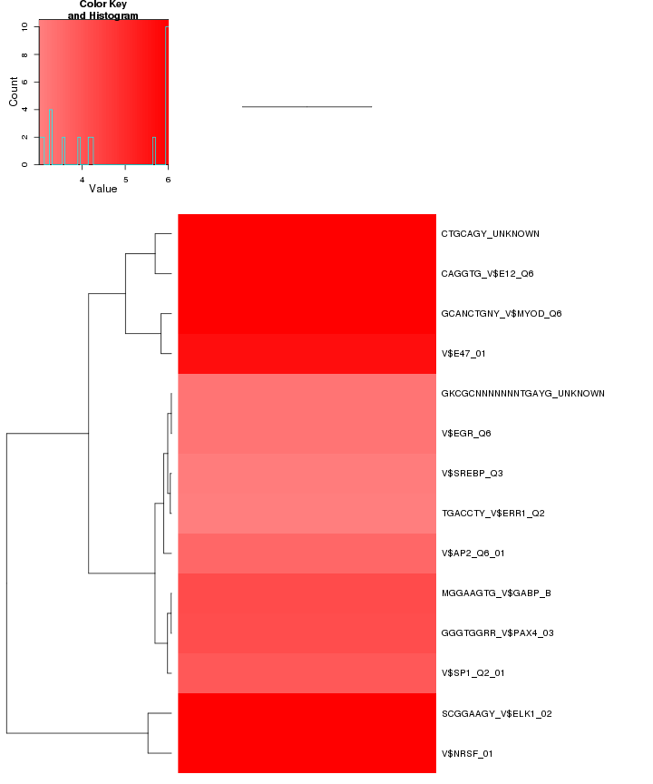

TF zscore:

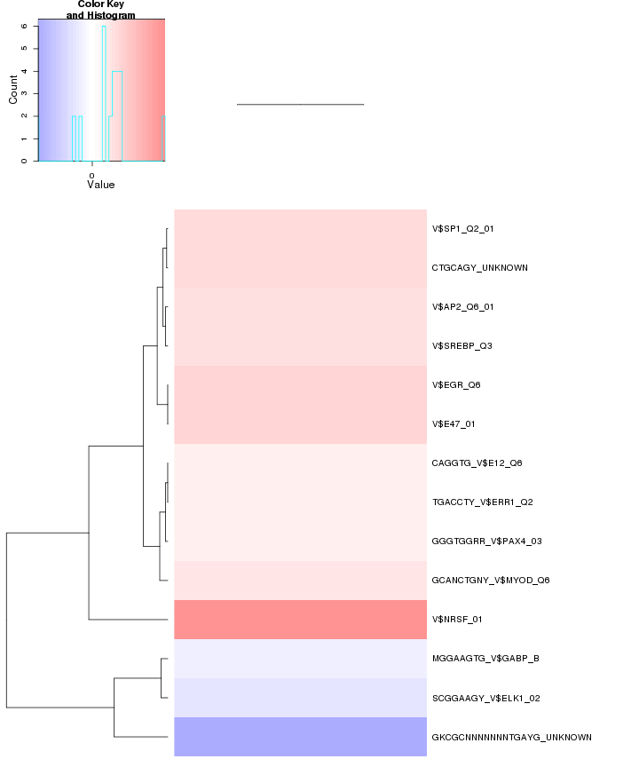

## GO enrichment

Cluster profiler used to call enichments of significantly differentially regulated genes that map to Entrez IDs.

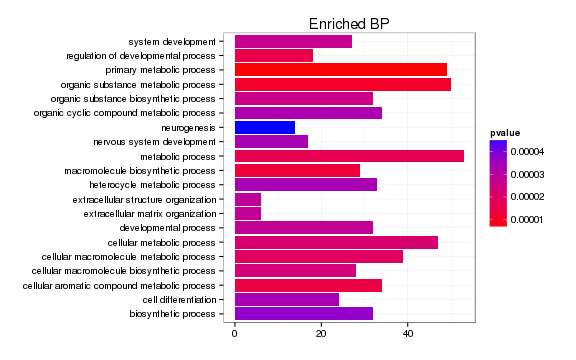

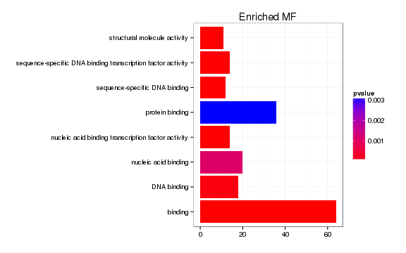

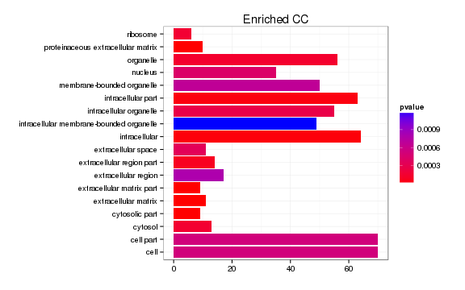

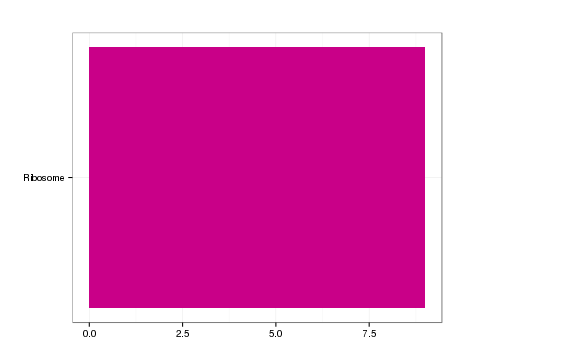

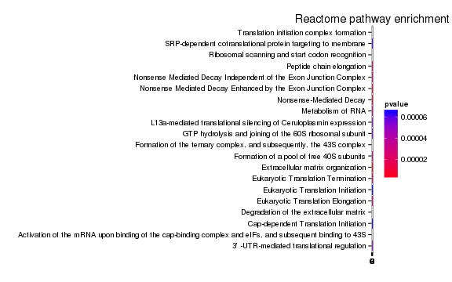

### Enrichment or depletion for stage-specific cell cycle markers

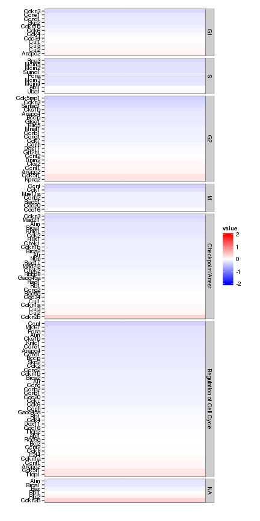

### Enrichment or depletion for markers of specific cortical layers

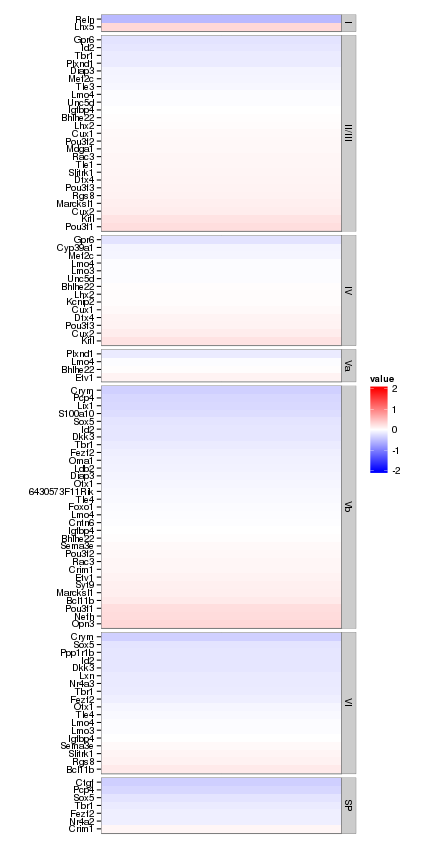

### Enrichment or depletion for specific neural cell types

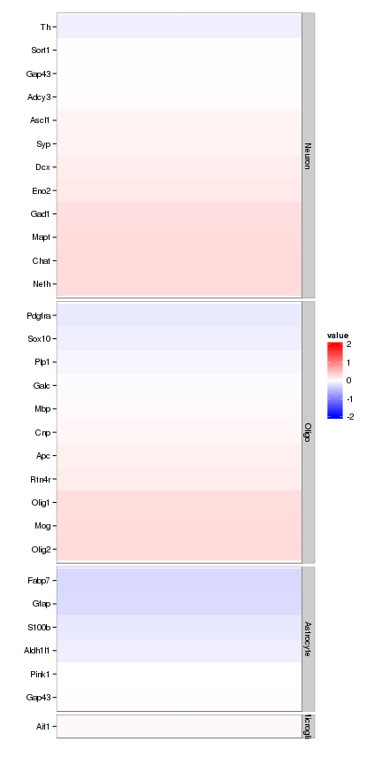

### Enrichment or Depletion of neural differentiation markers

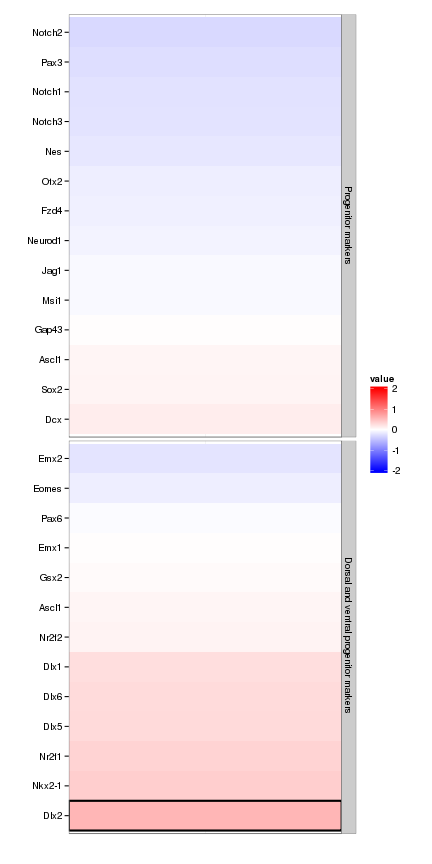

# Cis vs Trans (locally)

log2 Foldchange and test statistic are calculated with the ratio of fpkm(KO)/fpkm(WT), thus the test_stat is positive if a gene is higher in the KO and negative if a gene has lower expression in the KO

The pvalue for 0 genes significantly regulated in a region this size is: 1

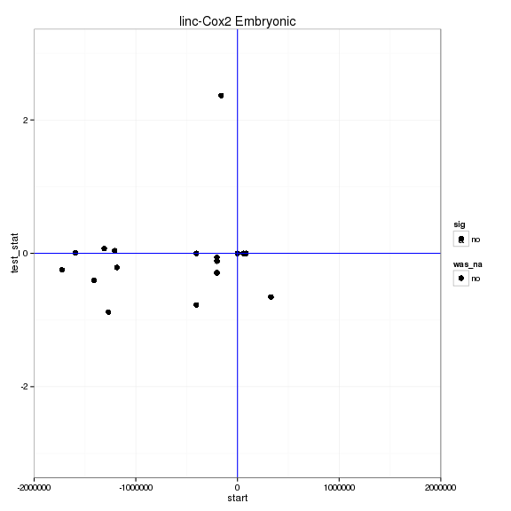

# Notes

## Samples used are:

|  | 10 |
| --- | --- |
| 1 | JR753 |
| 2 | JR750 |
| 3 | JR771 |
| 4 | JR755 |
| 5 | JR811 |
| 6 | JR768 |
| 7 | JR761 |
| 8 | JR815 |
| 9 | JR789 |
| 10 | JR748 |
| 11 | JR716 |
| 12 | JR717 |
| 13 | JR719 |
| 14 | JR756 |
| 15 | JR809 |
| 16 | JR816 |
| 17 | JR829 |

## Replicates

|  | file | sample_name | replicate | rep_name | total_mass | norm_mass | internal_scale | external_scale |
| --- | --- | --- | --- | --- | --- | --- | --- | --- |
| 1 | /n/rinn_data1/seq/lgoff/Projects/BrainMap/data/quants/JR753/abundances.cxb | WT | 0 | WT_0 | 39331900.00 | 32194900.00 | 1.27 | 1.00 |
| 2 | /n/rinn_data1/seq/lgoff/Projects/BrainMap/data/quants/JR750/abundances.cxb | WT | 1 | WT_1 | 36031100.00 | 32194900.00 | 1.10 | 1.00 |
| 3 | /n/rinn_data1/seq/lgoff/Projects/BrainMap/data/quants/JR771/abundances.cxb | WT | 2 | WT_2 | 38857100.00 | 32194900.00 | 1.23 | 1.00 |
| 4 | /n/rinn_data1/seq/lgoff/Projects/BrainMap/data/quants/JR755/abundances.cxb | WT | 3 | WT_3 | 41811300.00 | 32194900.00 | 1.29 | 1.00 |
| 5 | /n/rinn_data1/seq/lgoff/Projects/BrainMap/data/quants/JR811/abundances.cxb | WT | 4 | WT_4 | 38172800.00 | 32194900.00 | 1.21 | 1.00 |
| 6 | /n/rinn_data1/seq/lgoff/Projects/BrainMap/data/quants/JR768/abundances.cxb | WT | 5 | WT_5 | 28375200.00 | 32194900.00 | 0.90 | 1.00 |
| 7 | /n/rinn_data1/seq/lgoff/Projects/BrainMap/data/quants/JR761/abundances.cxb | WT | 6 | WT_6 | 31706200.00 | 32194900.00 | 0.98 | 1.00 |
| 8 | /n/rinn_data1/seq/lgoff/Projects/BrainMap/data/quants/JR815/abundances.cxb | WT | 7 | WT_7 | 29733100.00 | 32194900.00 | 0.93 | 1.00 |
| 9 | /n/rinn_data1/seq/lgoff/Projects/BrainMap/data/quants/JR789/abundances.cxb | WT | 8 | WT_8 | 27681500.00 | 32194900.00 | 0.86 | 1.00 |
| 10 | /n/rinn_data1/seq/lgoff/Projects/BrainMap/data/quants/JR748/abundances.cxb | WT | 9 | WT_9 | 32367000.00 | 32194900.00 | 0.96 | 1.00 |
| 11 | /n/rinn_data1/seq/lgoff/Projects/BrainMap/data/quants/JR716/abundances.cxb | WT | 10 | WT_10 | 26144700.00 | 32194900.00 | 0.81 | 1.00 |
| 12 | /n/rinn_data1/seq/lgoff/Projects/BrainMap/data/quants/JR717/abundances.cxb | WT | 11 | WT_11 | 25565400.00 | 32194900.00 | 0.80 | 1.00 |
| 13 | /n/rinn_data1/seq/lgoff/Projects/BrainMap/data/quants/JR719/abundances.cxb | WT | 12 | WT_12 | 22697800.00 | 32194900.00 | 0.69 | 1.00 |
| 14 | /n/rinn_data1/seq/lgoff/Projects/BrainMap/data/quants/JR756/abundances.cxb | WT | 13 | WT_13 | 38948900.00 | 32194900.00 | 1.22 | 1.00 |
| 15 | /n/rinn_data1/seq/lgoff/Projects/BrainMap/data/quants/JR809/abundances.cxb | linc_Cox2 | 0 | linc_Cox2_0 | 36051200.00 | 32194900.00 | 1.11 | 1.00 |
| 16 | /n/rinn_data1/seq/lgoff/Projects/BrainMap/data/quants/JR816/abundances.cxb | linc_Cox2 | 1 | linc_Cox2_1 | 31829200.00 | 32194900.00 | 0.98 | 1.00 |
| 17 | /n/rinn_data1/seq/lgoff/Projects/BrainMap/data/quants/JR829/abundances.cxb | linc_Cox2 | 2 | linc_Cox2_2 | 30833100.00 | 32194900.00 | 0.95 | 1.00 |

## Run Info

[output not shown]